# SUPPORT VECTOR MACHINE ANALYSIS

## By : Lade Sule, DSC 3344

```python
from sklearn import datasets
from sklearn.datasets import load_breast_cancer
from sklearn import svm
cancer = load_breast_cancer()
import pandas as pd
import numpy as np
from sklearn.model_selection import train_test_split
import seaborn as sns
import matplotlib.pyplot as plt
```

```python
cancer
#cancer['data'].astype(float).apply(lambda x: '{:.4f}'.format(x))
```

[output not shown]

#### In the first step of this analysis, I want to load in the actual dataset to get a better and more clear overview of all the features. In this dataframe there are about 569 records and 30 features, all contributing and having some correlation to whether a tumor is benign or malignant. Our target variable used in this dataset will be a binary outcome.

```python
data_df = pd.DataFrame(data = cancer.data,
                       columns = cancer.feature_names)
data_df.head(2)
```

|  | mean radius | mean texture | mean perimeter | mean area | mean smoothness | mean compactness | mean concavity | mean concave points | mean symmetry | mean fractal dimension | ... | worst radius | worst texture | worst perimeter | worst area | worst smoothness | worst compactness | worst concavity | worst concave points | worst symmetry | worst fractal dimension |
| --- | --- | --- | --- | --- | --- | --- | --- | --- | --- | --- | --- | --- | --- | --- | --- | --- | --- | --- | --- | --- | --- |
| 0 | 17.99 | 10.38 | 122.8 | 1001.0 | 0.11840 | 0.27760 | 0.3001 | 0.14710 | 0.2419 | 0.07871 | ... | 25.38 | 17.33 | 184.6 | 2019.0 | 0.1622 | 0.6656 | 0.7119 | 0.2654 | 0.4601 | 0.11890 |
| 1 | 20.57 | 17.77 | 132.9 | 1326.0 | 0.08474 | 0.07864 | 0.0869 | 0.07017 | 0.1812 | 0.05667 | ... | 24.99 | 23.41 | 158.8 | 1956.0 | 0.1238 | 0.1866 | 0.2416 | 0.1860 | 0.2750 | 0.08902 |

2 rows × 30 columns

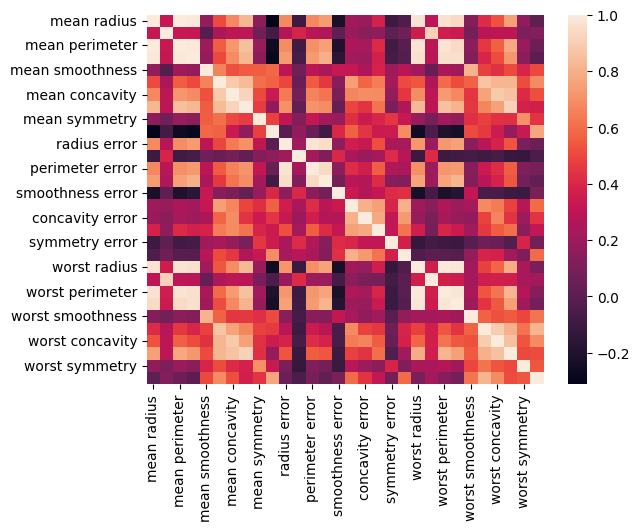

```python
correlation_matrix = data_df.corr()
correlation_matrix
sns.heatmap(correlation_matrix, annot = False)
```

#### Next, I incorporated Principal Component Analysis (PCA) as a dimensionality reduction technique. PCA allows the transformation of our high-dimensional feature space into a lower-dimensional representation while keeping "important" information. By using the principal components that explain the majority of the variance in the data, PCA enables us to reduce multicollinearity among features, just like stated up above. This helps simplifies the modeling process.

```python
from sklearn.decomposition import PCA
from sklearn.svm import SVC
from sklearn.pipeline import Pipeline
data = load_breast_cancer()
X = data.data
y = data.target
pca = PCA(n_components=2)
svc = SVC()
model = Pipeline([('pca', pca), ('svc', svc)])
model.fit(X, y)
```

```
Pipeline(steps=[('pca', PCA(n_components=2)), ('svc', SVC())])
```

#### Using Principal Component Analysis (PCA), I generated a new set of independent feature vectors, which greatly aided in our data analysis. By identifying the principal components from the original feature space, PCA allowed us to create a transformed set of x-values that were uncorrelated to each other. Below is the new set of X values that will be used to build the model.

```python
X_reduced = pca.transform(X).copy()
np.shape(X_reduced)
```

[output not shown]

```python
X_train,X_test,y_train,y_test = train_test_split(X_reduced,y, test_size = .3,random_state=42)
from sklearn import svm
```

```python
clf = svm.SVC(kernel = 'linear', C=1).fit(X_train,y_train)
y_pred = clf.predict(X_test)
C=1.0
h=.2
#svc = svm.SVC(kernel='linear',C=C).fit(X_train,y_train)
```

#### After calculating the accuracy of the model with our testing data, it scored .96 (may slightly differ each time it is ran). This high level of accuracy serves as a strong indicator of the model's ability to effectively classify and generalize patterns in the data.

```python
from sklearn import metrics
print("Accuracy:",metrics.accuracy_score(y_test, y_pred))
```

```
Accuracy: 0.9649122807017544
```

```python
x_min, x_max = X_train[:, 0].min() - 1, X_train[:, 0].max() + 1
y_min, y_max = X_train[:, 1].min() - 1,X_train[:, 1].max() + 1
xx, yy = np.meshgrid(np.arange(x_min, x_max, h),
                     np.arange(y_min, y_max, h))
```

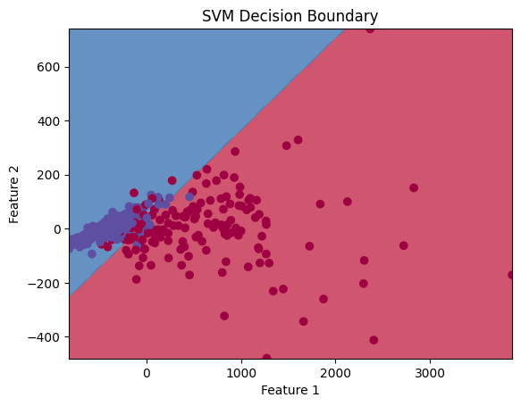

```python
h = 0.01 # Step size in the mesh
Z = clf.predict(np.c_[xx.ravel(), yy.ravel()])
Z = Z.reshape(xx.shape)
plt.contourf(xx, yy, Z, cmap=plt.cm.Spectral, alpha=0.8)
plt.scatter(X_train[:, 0], X_train[:, 1], c=y_train, cmap=plt.cm.Spectral)
plt.xlabel('Feature 1')
plt.ylabel('Feature 2')
plt.title('SVM Decision Boundary')
plt.show()
```